[figure not shown]

# Introduction to Classification

## Icebreaker

To get into the mindset of classification, discuss **two** examples of classification with your neighbour.

If it's related to your own project, even better!

# Learning Objectives / Agenda

### Introduction to Classification

### kNN

### Precision and accuracy

## Introduction to Classification

```python
from sklearn.datasets import load_iris

iris = load_iris()
iris.keys()
```

```
dict_keys(['data', 'target', 'target_names', 'DESCR', 'feature_names'])
```

Making iris a DataFrame

```python
df = pd.DataFrame(iris.data, columns=iris.feature_names)
df["target"] = iris.target
df["target"] = df["target"].map({idx:name for idx, name in enumerate(iris.target_names)})
df.head()
```

|  | sepal length (cm) | sepal width (cm) | petal length (cm) | petal width (cm) | target |
| --- | --- | --- | --- | --- | --- |
| 0 | 5.1 | 3.5 | 1.4 | 0.2 | setosa |
| 1 | 4.9 | 3.0 | 1.4 | 0.2 | setosa |
| 2 | 4.7 | 3.2 | 1.3 | 0.2 | setosa |
| 3 | 4.6 | 3.1 | 1.5 | 0.2 | setosa |
| 4 | 5.0 | 3.6 | 1.4 | 0.2 | setosa |

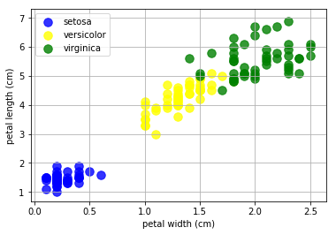

```python
setosa_df = df[df["target"] == "setosa"].copy()
versicolor_df = df[df["target"] == "versicolor"].copy()
virginica_df = df[df["target"] == "virginica"].copy()


plt.scatter(setosa_df["petal width (cm)"], setosa_df["petal length (cm)"], alpha=0.8, s=90, c="blue", label="setosa")
plt.scatter(versicolor_df["petal width (cm)"], versicolor_df["petal length (cm)"], alpha=0.8, s=90, c="yellow", label="versicolor")
plt.scatter(virginica_df["petal width (cm)"], virginica_df["petal length (cm)"], alpha=0.8, s=90, c="green", label="virginica")
plt.grid()
plt.xlabel("petal width (cm)")
plt.ylabel("petal length (cm)")
plt.legend(loc=2)
plt.show()
```

What class is this new point?

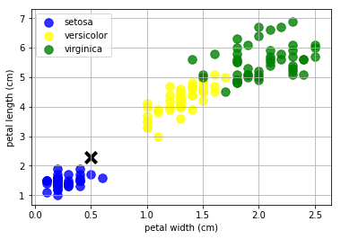

```python
plt.scatter(setosa_df["petal width (cm)"], setosa_df["petal length (cm)"], alpha=0.8, s=90, c="blue", label="setosa")
plt.scatter(versicolor_df["petal width (cm)"], versicolor_df["petal length (cm)"], alpha=0.8, s=90, c="yellow", label="versicolor")
plt.scatter(virginica_df["petal width (cm)"], virginica_df["petal length (cm)"], alpha=0.8, s=90, c="green", label="virginica")
plt.scatter([0.5], [2.3], c="k", marker="x", s=150, linewidth=4);plt.grid()
plt.xlabel("petal width (cm)")
plt.ylabel("petal length (cm)")
plt.legend(loc=2)
plt.show()
```

What about this one?

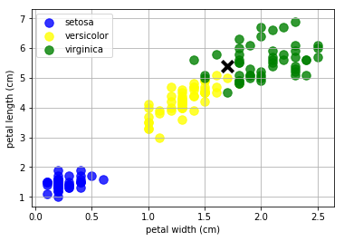

```python
plt.scatter(setosa_df["petal width (cm)"], setosa_df["petal length (cm)"], alpha=0.8, s=90, c="blue", label="setosa")
plt.scatter(versicolor_df["petal width (cm)"], versicolor_df["petal length (cm)"], alpha=0.8, s=90, c="yellow", label="versicolor")
plt.scatter(virginica_df["petal width (cm)"], virginica_df["petal length (cm)"], alpha=0.8, s=90, c="green", label="virginica")
plt.scatter([1.7], [5.4], c="k", marker="x", s=150, linewidth=4);plt.grid()
plt.xlabel("petal width (cm)")
plt.ylabel("petal length (cm)")
plt.legend(loc=2)
plt.show()
```

### Exercise

Could we construct a "classifier" manually based on this plot?

With a partner, discuss and fill in the function at the bottom of notebook 16.

# K Nearest Neighbours

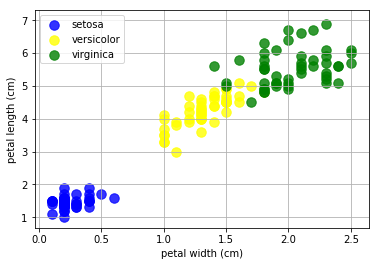

```python
plt.scatter(setosa_df["petal width (cm)"], setosa_df["petal length (cm)"], alpha=0.8, s=90, c="blue", label="setosa")
plt.scatter(versicolor_df["petal width (cm)"], versicolor_df["petal length (cm)"], alpha=0.8, s=90, c="yellow", label="versicolor")
plt.scatter(virginica_df["petal width (cm)"], virginica_df["petal length (cm)"], alpha=0.8, s=90, c="green", label="virginica")
plt.grid()
plt.xlabel("petal width (cm)")
plt.ylabel("petal length (cm)")
plt.legend(loc=2)
plt.show()
```

The boundary between `versicolor` and `virginica` is hard to separate using "if-then" rules only

#### Idea

- what about looking at a new point's neighbourhood to determine its class?
- this is what KNN does

### The algorithm

- choose a value $k$
- for a point we want to predict, find its $k$ neighbours
- the default is Euclidean distance, but there are other options
- take the most frequent class in its $k$ neighbours: that's your prediction!

What is $k$ an example of?

$k$ is another example of a **hyperparameter**.

The preferred value of $k$ is usually **odd**. Why?

What if there **is** a tie?

- flip a coin (bad)
- sort out the tie by weighting observations by distance (better!)
- this is **probably** what `scikit-learn` does (here's a discussion: https://stats.stackexchange.com/questions/144718/how-does-scikit-learn-resolve-ties-in-the-knn-classification)
- other ideas include adding/taking away neighbours until the tie is broken

## Explanation

In the following scatter plot, a dataset formed of blue and red samples is shown

[figure not shown]

A new sample is recorded, but it's not labelled. Which class does it belong to? Is this a red or a blue?

[figure not shown]

Let's check its nearest neighbours, in this case `k=5`

[figure not shown]

The k-Nearest Neighbours have the following characteristics:

[figure not shown]

| Sample | Class | Distance |
| --- | --- | --- |
| A | Blue | 1.7532 |
| B | Blue | 2.0927 |
| C | Red | 3.2397 |
| D | Red | 3.4082 |
| E | Red | 3.243 |

### Options

- 3 neighbours are red, 2 are blue, the sample is red
- blue neighbours have a average shorter distance, the sample is blue
- number of neighbours and distance must be weighted
- let's change `k` and see what happens
- let's pick the kNN for each class and check the average distance then

...

## Advantages

- simple to understand
- there is no "training" as such: we have to check the neighbours on the fly
- it can also be used for regression: **how?**

## Disadvantages

- prediction can take longer for large datasets: **why?**
- it doesn't tell us anything about feature importance
- works worse with more columns (in high-dimensional space, everything is far away...)

## KNN on Iris

```python
from sklearn.model_selection import train_test_split
from sklearn.neighbors import KNeighborsClassifier
from sklearn.metrics import accuracy_score

X_train, X_test, y_train, y_test = train_test_split(df.drop("target", axis=1),
                                                    df["target"],
                                                    test_size=0.3,
                                                    random_state=1)
knn = KNeighborsClassifier(n_neighbors=7)
knn.fit(X_train, y_train)
y_pred = knn.predict(X_test)
accuracy_score(y_test, y_pred)
```

```
0.9777777777777777
```

## Precision and accuracy

When working with classification, our predictions can be either true or false in relation to a class prediction and these figures help us define the quality of our model.

If we want to classify, for example, whether a loan application will be `successful` or `rejected` we can have the following figures:

- True Positives (**TP**): applications we classified as successful that were actually successful
- False Positives (**FP**): applications we classified as successful that were actually rejected
- True Negatives (**TN**): applications we classified as unsuccessful that were actually rejected
- False Negatives (**FN**): applications we classified as unsuccessful that were actually successful

Starting from these results we can measure our model's **precision** and **accuracy**.

The **precision** is calculated as:

$$ precision = {\frac {TP} {TP + FP}}$$

The **accuracy** is calculated as:

$$ accuracy = {\frac {TP + TN} {TP + FP + TN + FN}}$$

Since your model will have to be a compromise between optimising precision and accuracy, you may have to choose.

The choice will depend on your priorities:

A) I'd rather flag as `successful` only the applications that I'm sure will be successful

B) I'd rather not miss any `successful` applications

[figure not shown]

`successful` = red

`rejected` = blue

Option A)

[figure not shown]

- TP = 6
- FP = 0
- TN = 16
- FN = 8

`precision` = 100%

`accuracy` = 73.33%

Option B)

[figure not shown]

- TP = 14
- FP = 5
- TN = 11
- FN = 0

`precision` = 73.68%

`accuracy` = 83.33%